# EXPLORATORY DATA ANALYSIS by Kemal Kar

```
##   X fixed.acidity volatile.acidity citric.acid residual.sugar chlorides
## 1 1           7.4             0.70        0.00            1.9     0.076
## 2 2           7.8             0.88        0.00            2.6     0.098
## 3 3           7.8             0.76        0.04            2.3     0.092
## 4 4          11.2             0.28        0.56            1.9     0.075
## 5 5           7.4             0.70        0.00            1.9     0.076
## 6 6           7.4             0.66        0.00            1.8     0.075
##   free.sulfur.dioxide total.sulfur.dioxide density   pH sulphates alcohol
## 1                  11                   34  0.9978 3.51      0.56     9.4
## 2                  25                   67  0.9968 3.20      0.68     9.8
## 3                  15                   54  0.9970 3.26      0.65     9.8
## 4                  17                   60  0.9980 3.16      0.58     9.8
## 5                  11                   34  0.9978 3.51      0.56     9.4
## 6                  13                   40  0.9978 3.51      0.56     9.4
##   quality
## 1       5
## 2       5
## 3       5
## 4       6
## 5       5
## 6       5
```

```
##  [1] "X"                    "fixed.acidity"        "volatile.acidity"
##  [4] "citric.acid"          "residual.sugar"       "chlorides"
##  [7] "free.sulfur.dioxide"  "total.sulfur.dioxide" "density"
## [10] "pH"                   "sulphates"            "alcohol"
## [13] "quality"
```

# Univariate Plots Section

```r
summary(RedWineQuality)
```

```
##        X          fixed.acidity   volatile.acidity  citric.acid
##  Min.   :   1.0   Min.   : 4.60   Min.   :0.1200   Min.   :0.000
##  1st Qu.: 400.5   1st Qu.: 7.10   1st Qu.:0.3900   1st Qu.:0.090
##  Median : 800.0   Median : 7.90   Median :0.5200   Median :0.260
##  Mean   : 800.0   Mean   : 8.32   Mean   :0.5278   Mean   :0.271
##  3rd Qu.:1199.5   3rd Qu.: 9.20   3rd Qu.:0.6400   3rd Qu.:0.420
##  Max.   :1599.0   Max.   :15.90   Max.   :1.5800   Max.   :1.000
##  residual.sugar     chlorides       free.sulfur.dioxide
##  Min.   : 0.900   Min.   :0.01200   Min.   : 1.00
##  1st Qu.: 1.900   1st Qu.:0.07000   1st Qu.: 7.00
##  Median : 2.200   Median :0.07900   Median :14.00
##  Mean   : 2.539   Mean   :0.08747   Mean   :15.87
##  3rd Qu.: 2.600   3rd Qu.:0.09000   3rd Qu.:21.00
##  Max.   :15.500   Max.   :0.61100   Max.   :72.00
##  total.sulfur.dioxide    density             pH          sulphates
##  Min.   :  6.00       Min.   :0.9901   Min.   :2.740   Min.   :0.3300
##  1st Qu.: 22.00       1st Qu.:0.9956   1st Qu.:3.210   1st Qu.:0.5500
##  Median : 38.00       Median :0.9968   Median :3.310   Median :0.6200
##  Mean   : 46.47       Mean   :0.9967   Mean   :3.311   Mean   :0.6581
##  3rd Qu.: 62.00       3rd Qu.:0.9978   3rd Qu.:3.400   3rd Qu.:0.7300
##  Max.   :289.00       Max.   :1.0037   Max.   :4.010   Max.   :2.0000
##     alcohol         quality
##  Min.   : 8.40   Min.   :3.000
##  1st Qu.: 9.50   1st Qu.:5.000
##  Median :10.20   Median :6.000
##  Mean   :10.42   Mean   :5.636
##  3rd Qu.:11.10   3rd Qu.:6.000
##  Max.   :14.90   Max.   :8.000
```

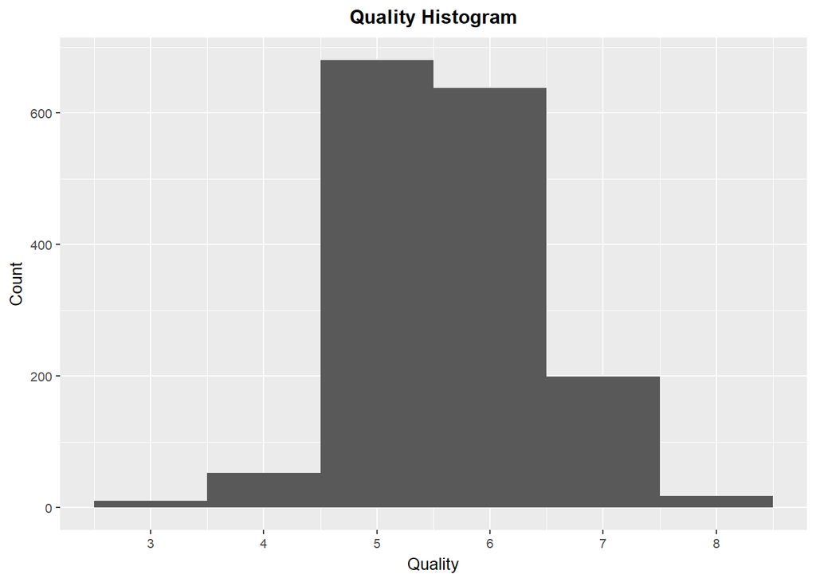

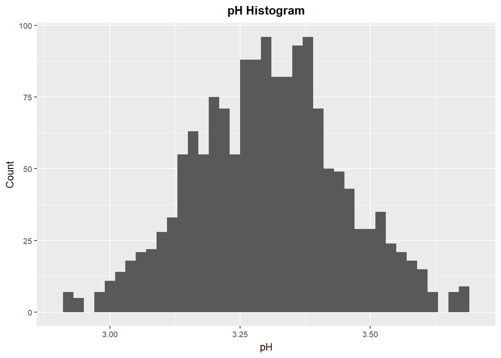

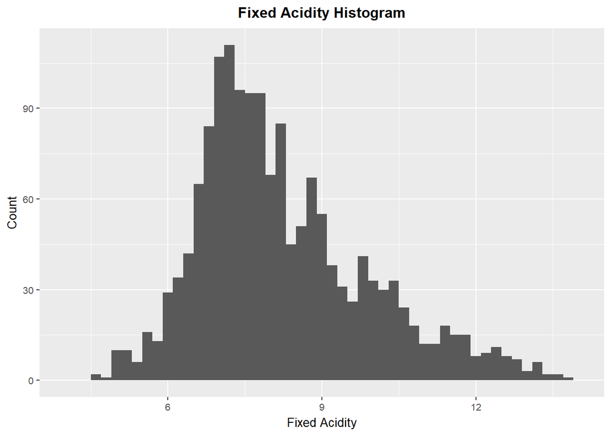

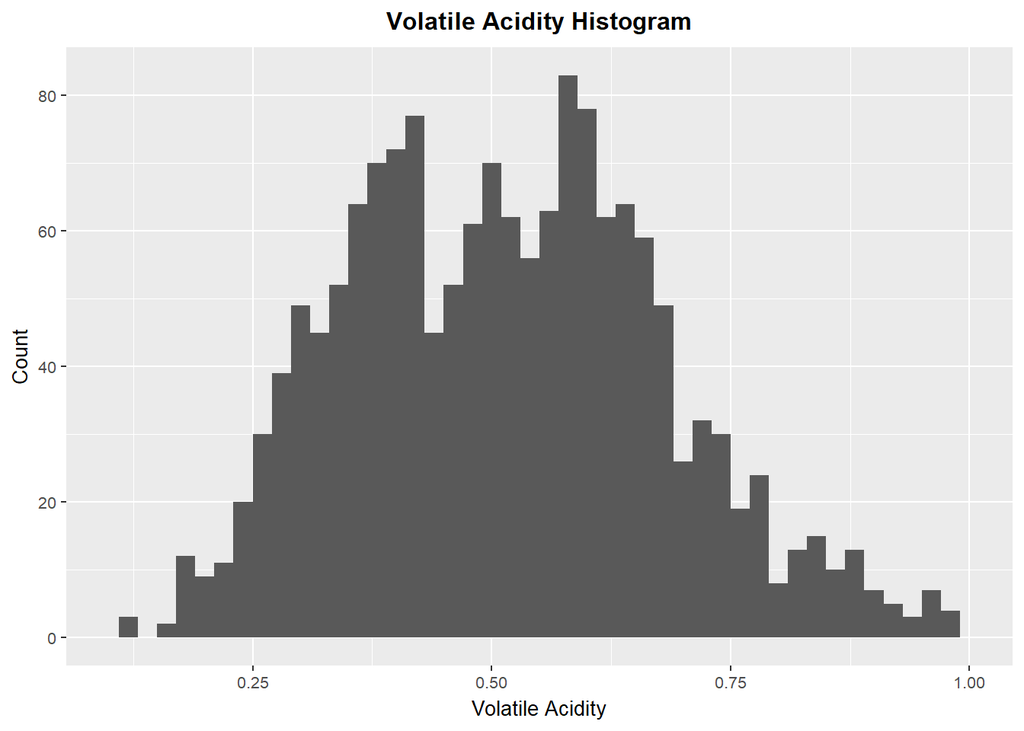

```
##    Min. 1st Qu.  Median    Mean 3rd Qu.    Max.
##   0.000   0.090   0.260   0.271   0.420   1.000
```

```
##    Min. 1st Qu.  Median    Mean 3rd Qu.    Max.
## 0.00000 0.03743 0.10037 0.09908 0.15229 0.30103
```

```
##    Min. 1st Qu.  Median    Mean 3rd Qu.    Max.
##  0.0000  0.3000  0.5099  0.4668  0.6481  1.0000
```

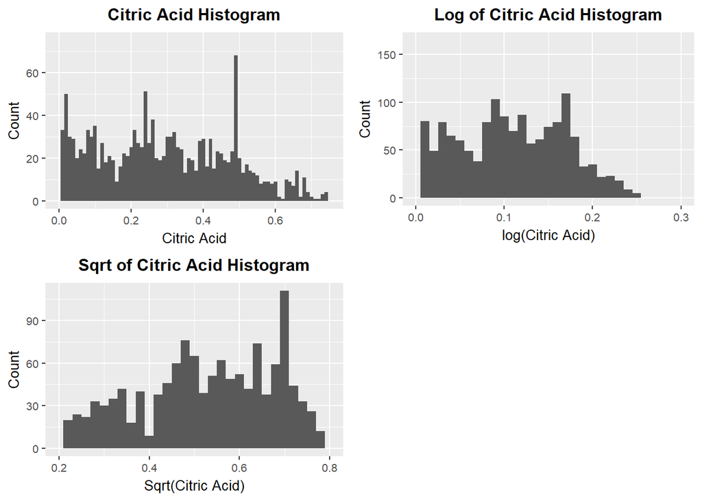

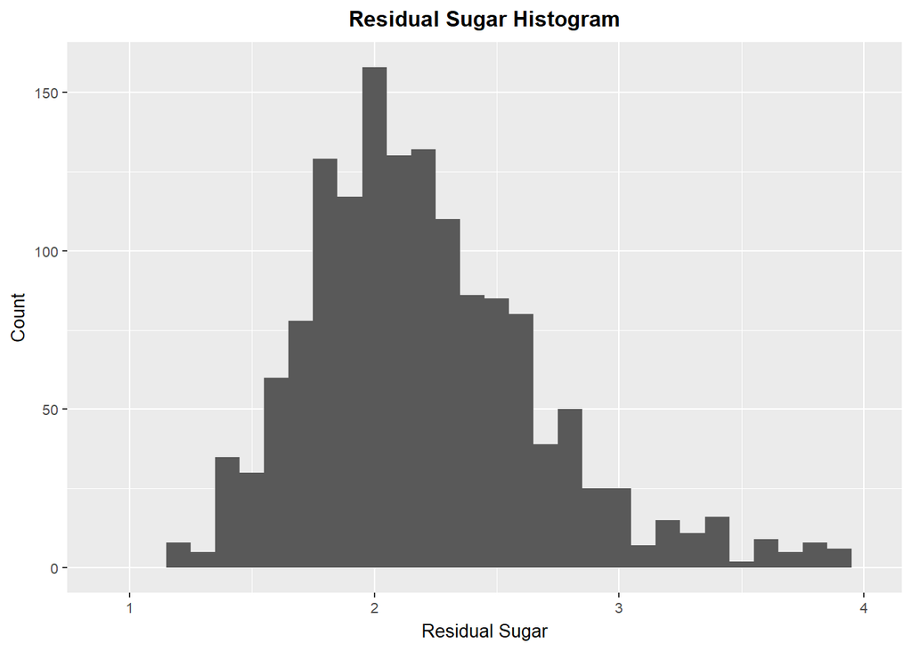

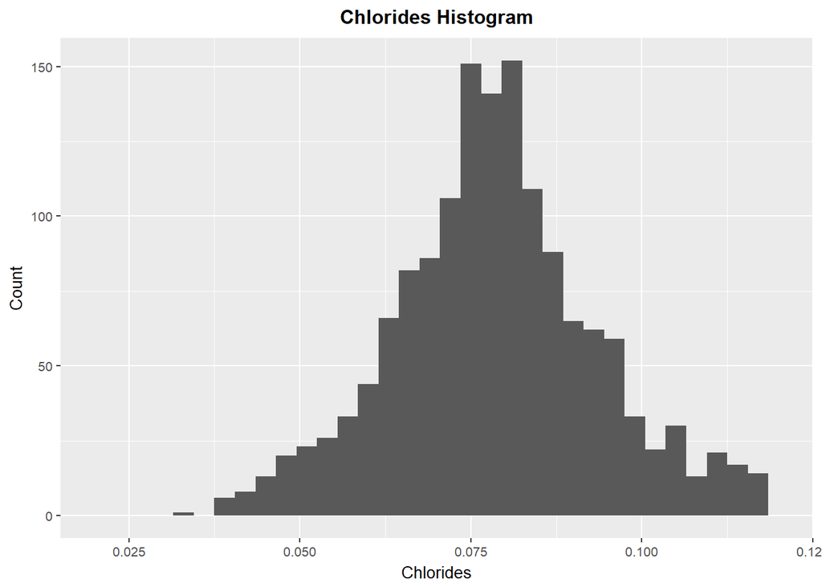

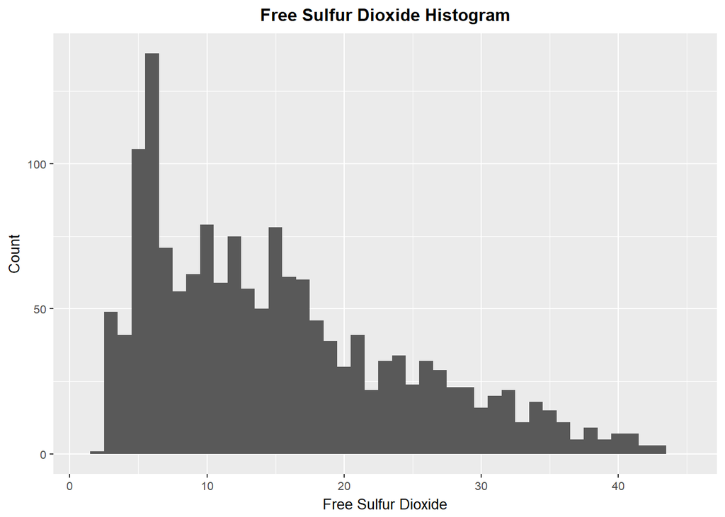

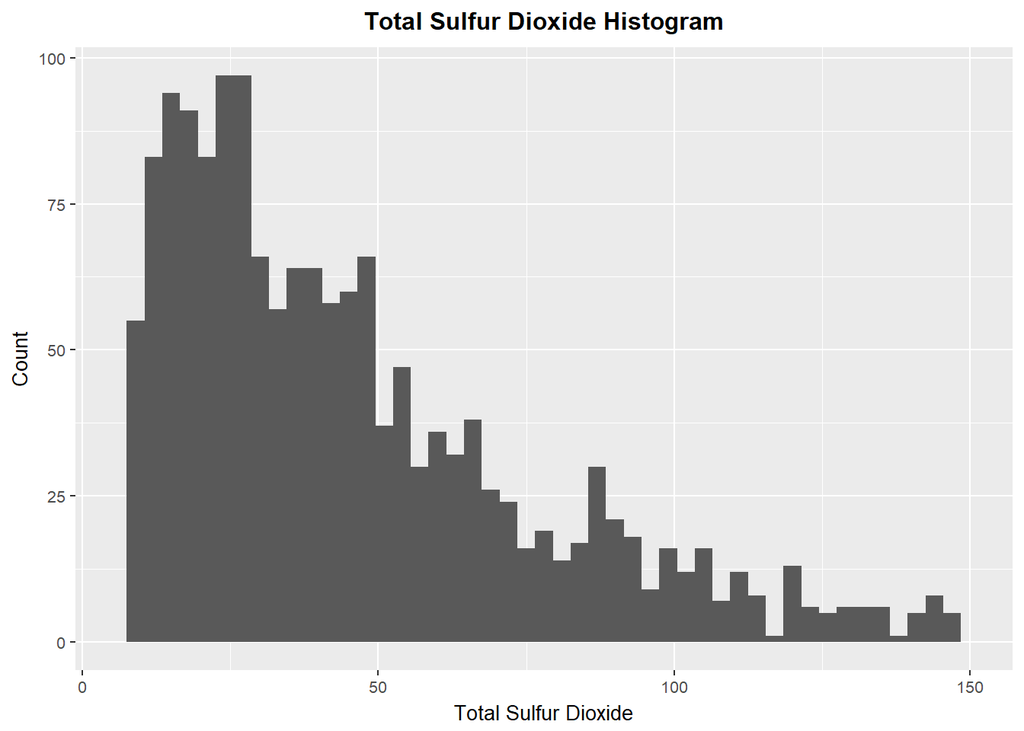

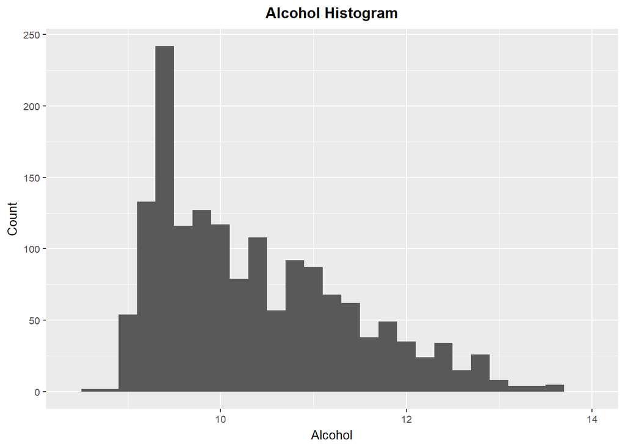

# Univariate Analysis

> **Tip**: Now that you’ve completed your univariate explorations, it’s time to reflect on and summarize what you’ve found. Use the questions below to help you gather your observations and add your own if you have other thoughts!

### What is the structure of your dataset?

Quality is the response variable in the dataset. The histogram displays that it is in normal distribution.

The explanatory variables in this dataset are quantitative. Some of them are explored in univariate plots:

### What is/are the main feature(s) of interest in your dataset?

Quality of the wine is a result of sulfur, acidity, sugar and chloride variables. Throughout the analysis below, I will assess the correlation between the quality and these variables.

Quality and the 1st group of variables above are in normal distribution. I will test whether this similarity in distribution means there is strong correlation between these variables and the resultant quality.

pH value can be a resultant value of fixed, volalite acidity and citric acid variables. I will assess whether there is a relationship between these variables and pH value.

Total and free sulfur dioxide distibutions are very similarly right skewed. I will also check whether these 2 variables are strongly corelated.

### Did you create any new variables from existing variables in the dataset?

At first check, no new variables are created.

### Of the features you investigated, were there any unusual distributions?

Throughout the histograms, I removed the long tails of some of the variables by cutting from the 1st and 3rd quadrants so that I could focus on the main distribution omitting the outliers.

Citric acid values seem to be distributed throughout the histogram plot. I checked the log and sqrt distributions if there could be a gaussian distribution hidden.

# Bivariate Plots Section

In this section, The correlation between different explanatory variables and the resultant variable, quality.

Let’s start with creating a heatmap which displays the correlations between different variables.

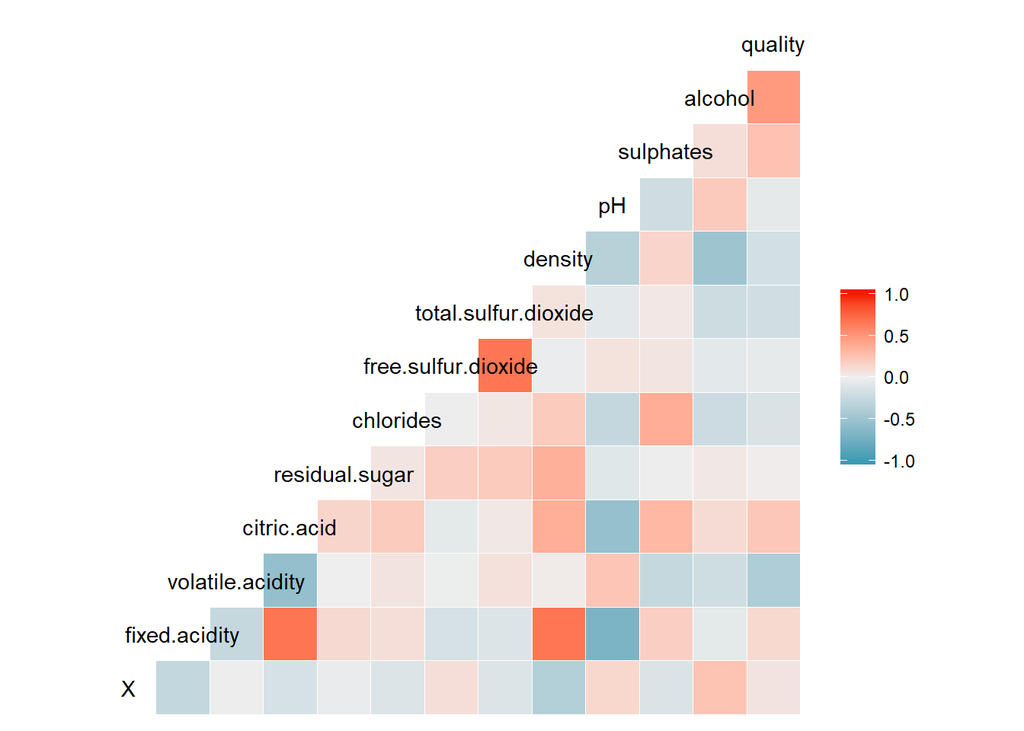

In the heatmap, the following correlations can be observed: 1. In higher quality wines, the alcohol , sulphates and citric acid is found more. There is a positive relationship between quality and these variables. 2. Volatile acidity is found less in hihger quality wines where as citric acid increases. 3. pH value of the wine is negatively correlated to fixed acidity and citric acid and positively correlated with volatile acidity. 4. Fixed acidity is very strongly correlated to citric acid and density of the wine. 5. Total and free sulfur dioxide is strongly correlated with each other.

As a second step, I will make a detailed analysis of these correlations in below chapters.

## The relationship between pH and Quality:

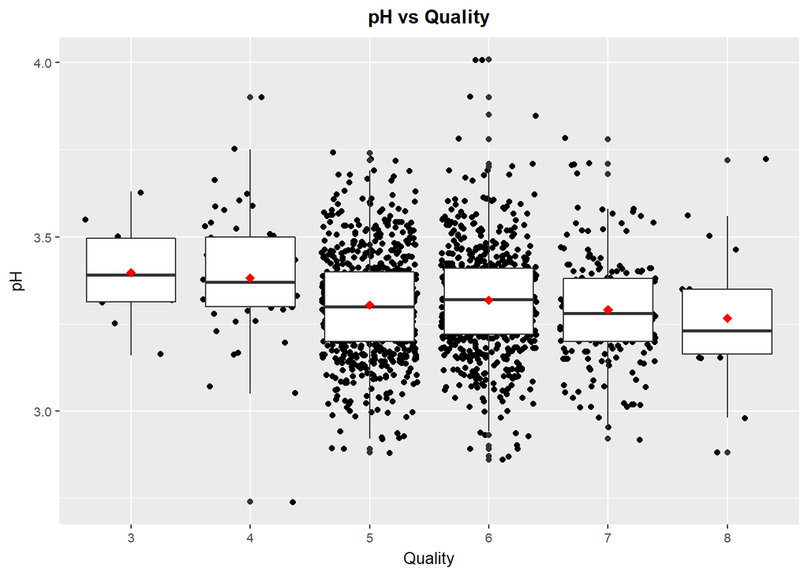

Inspecting the boxplots for each quality level, it can be observed that pH value is slightly decreasing while the quality of wine increases.

Contrary to my expectation, there is a weak correlation between the pH value and the quality. In the prior research about wine quality, it is said that pH value is important for the quality of wine.

## The relationship between Fixed Acidity and Quality:

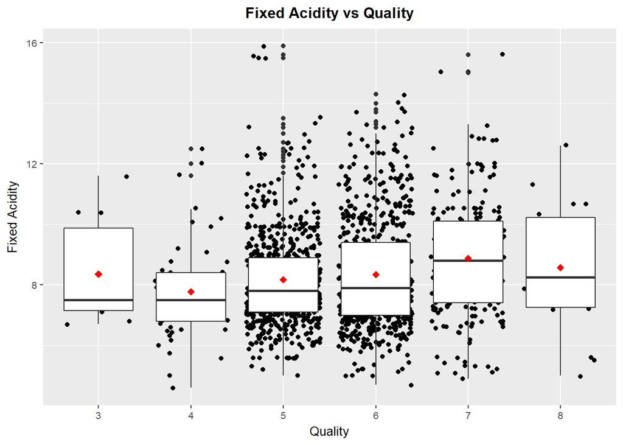

In general positive correlation is observed between Quality and Fixed Acidity. Fixed acidity in the wine increases in higher quality wines. However, there is not a continuous increase as fixed acidity values are nearly same in quality 3 and 8 wine samples.

## The relationship between Volatile Acidity and Quality:

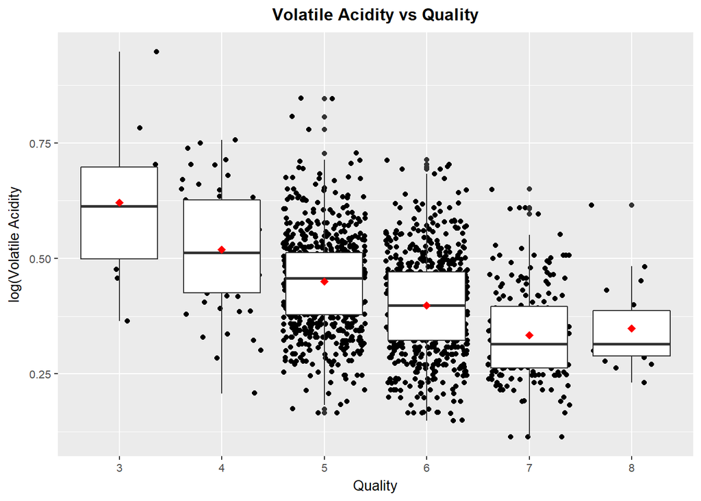

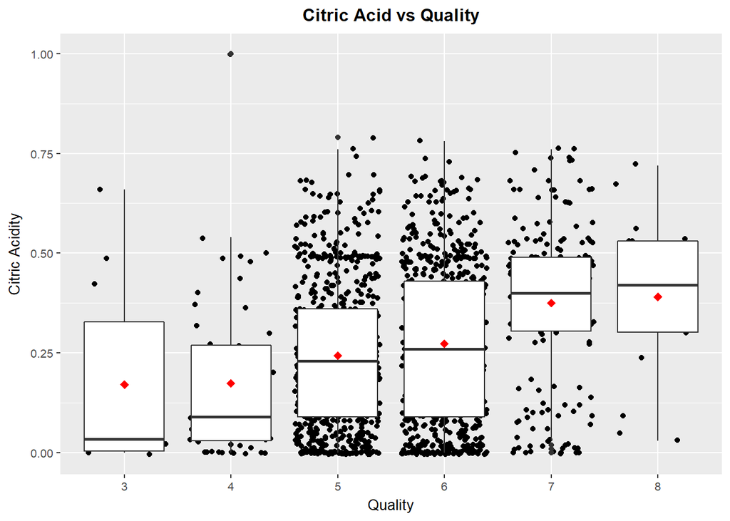

There is a positive relationship between the quality and citric acid value of wine.

Throughout the assessment of relationship between quality and acidity variables, it is observed that the most strong relationship is between volatile acidity and quality. In order to make better understandable visual analysis, I decided to use Volatile Acidity as the acidity variable.

## The relationship between Chloride and Quality:

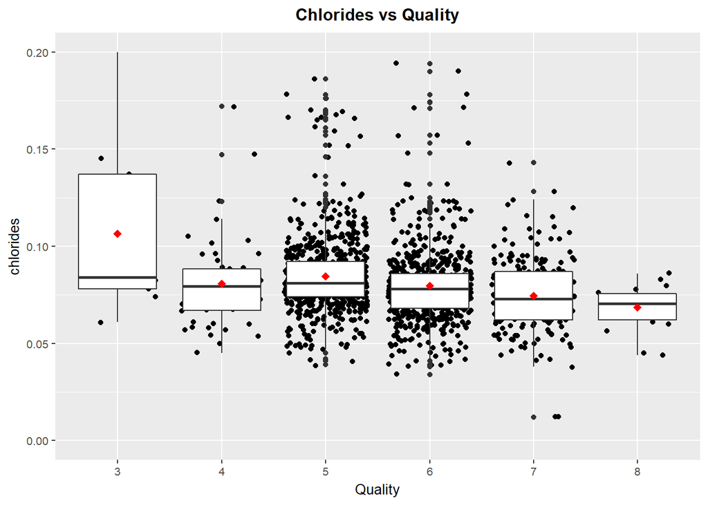

A very weak negative relationship is found between the quality of wine and the chlorides level in it.

Please note that in order to display the ditribution of chlorides, y scale is limited to exclude far outliers.

## The relationship between Total sulfur Dioxide and Quality:

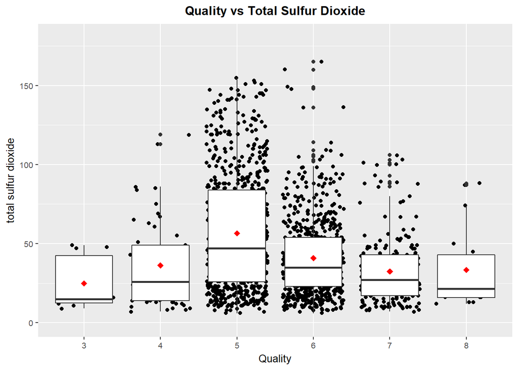

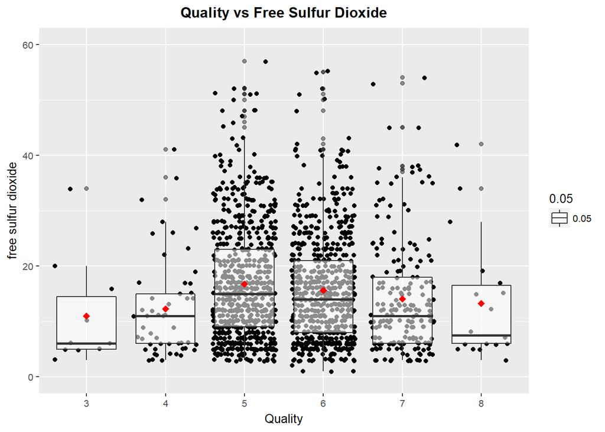

The same situation with the total sulfur dioxide is observed also with the free sulfur dioxide. There is a weak corelation between the sulfur dioxide levels and the quality.

Another observation from the heatmap and the last 2 plots above, total and free sulfur dioxide levels are correlated. Note that the change pattern against quality are very similar.

Let’s make another analysis to see total and free sulfur dioxide correlation explicitly:

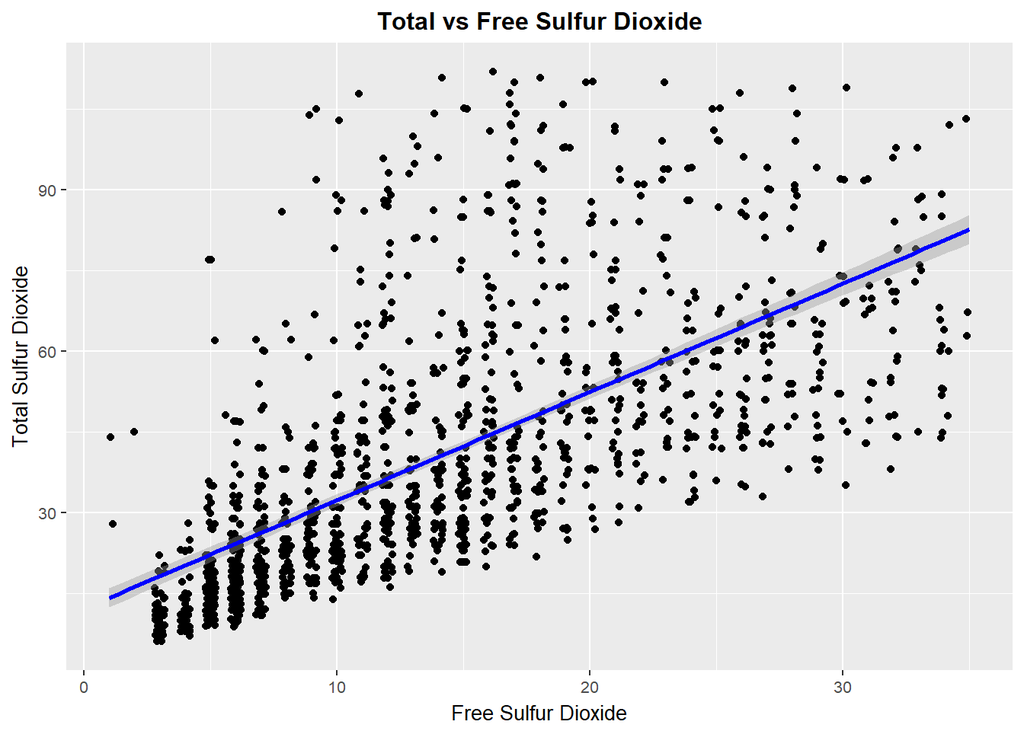

It is observed that total and free sulfur dioxide levels in wine samples are in strong positive correlation. This finding also coincides with the analysis of quality vs total and free sulfur dioxide variables.

## The relationship between Alcohol and Quality:

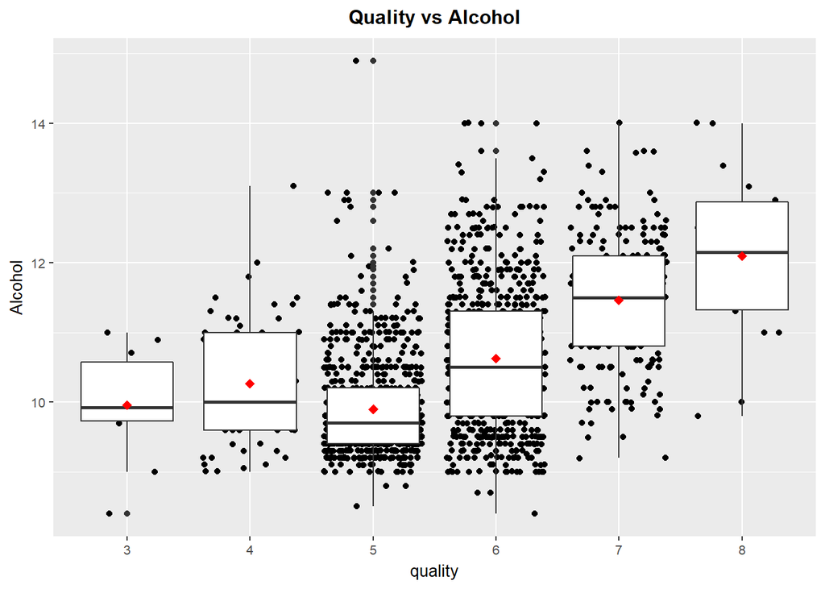

There is a strong relatipnship between the alcohol level and quality of the wine. We can see lower (than expected) alcohol (mean and median) values for quality level 5.

## The relationship between Sulphate and Quality:

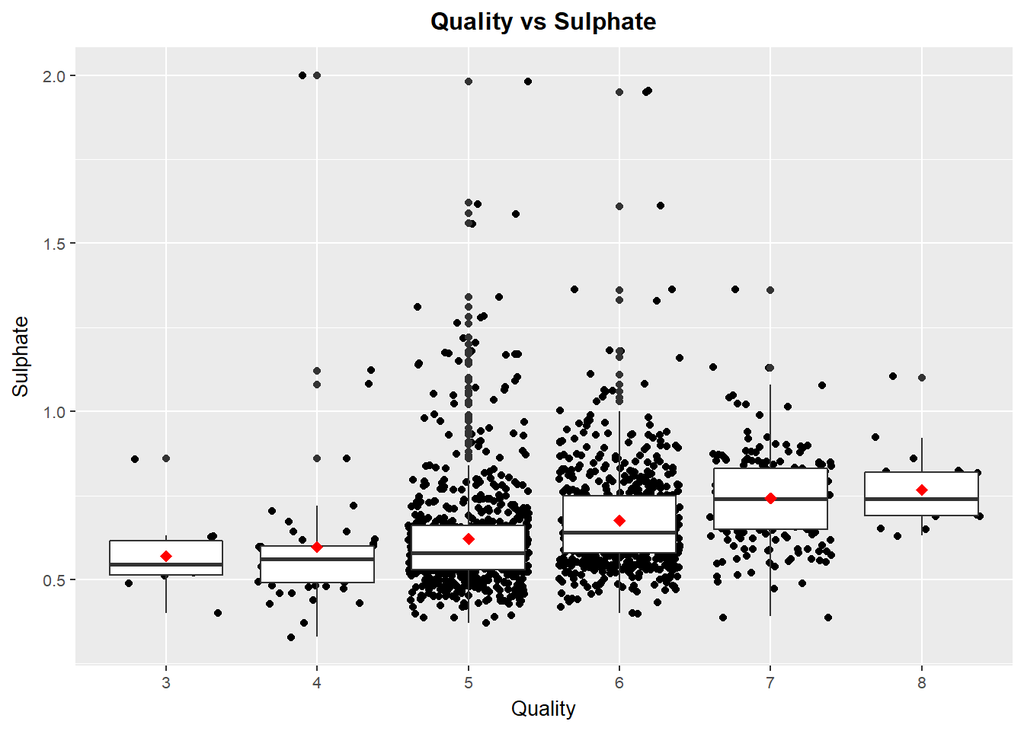

The quality of the wine is positively affected by sulphate level inside.

## The relationship between Fixed Acidity, Volatile acidity, Citric Acid and Quality:

## 1. The relationship between pH and Fixed Acidity

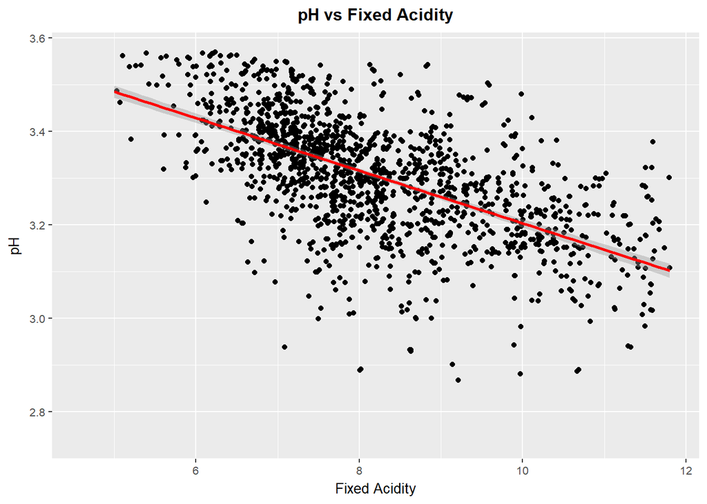

There is a strong negative correlation between pH and fixed acidity. As the fixed acidity increases, the pH value decreases steadily.

## 2. The relationship between pH and Volatile Acidity

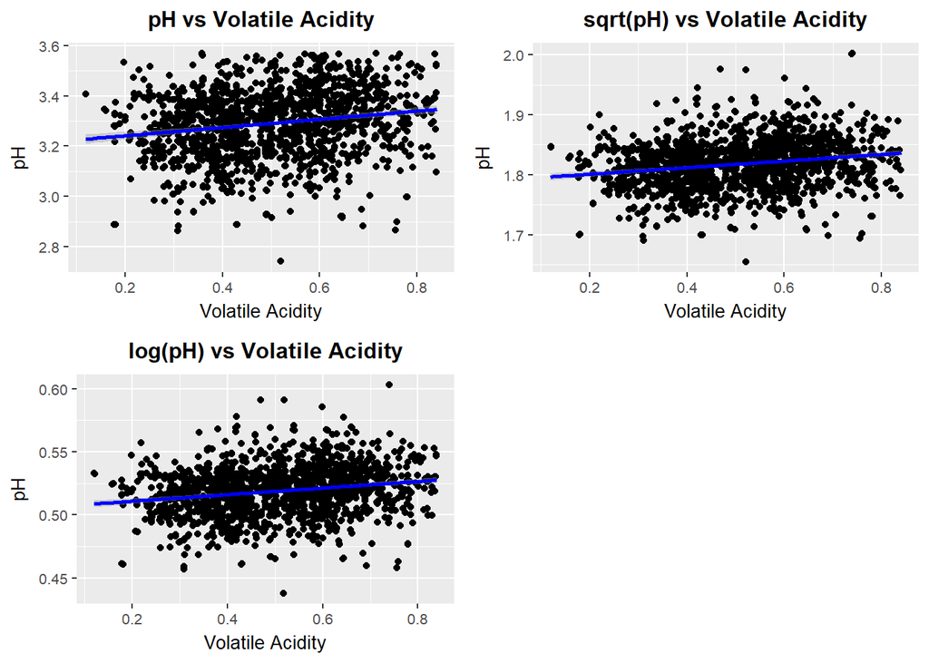

pH and volatile acidity are in positive correlation. I tried to check if there is a stronger relations exist between different transformation of pH an volatile acidity. However, there seems no important difference between trials.

## 3. The relationship between Volatile and Fixed Acidity

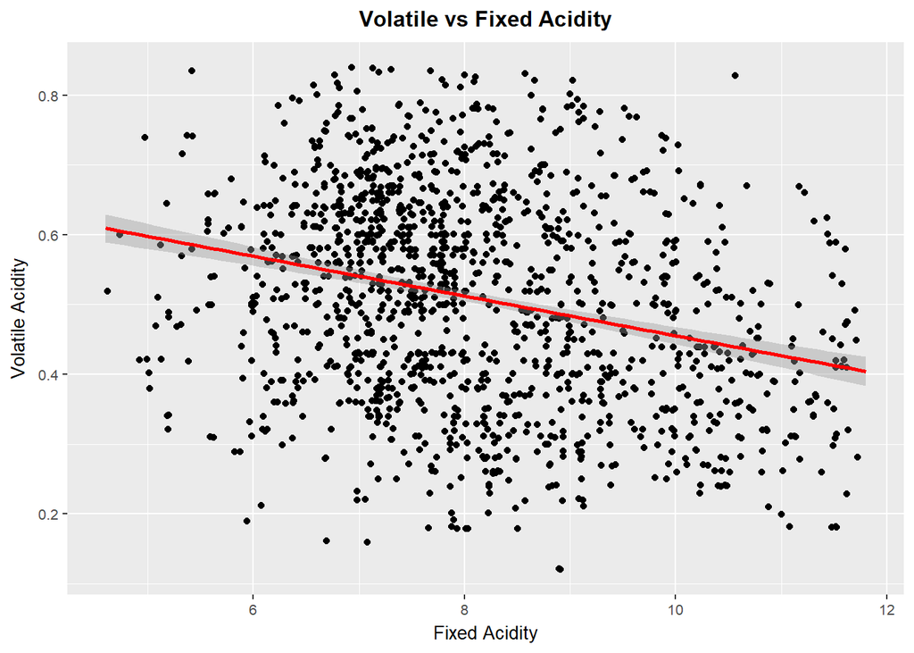

There is a weak negative correlation between Volatile and Fixed Acidity levels.

## 4. The relationship between pH and Citric Acid

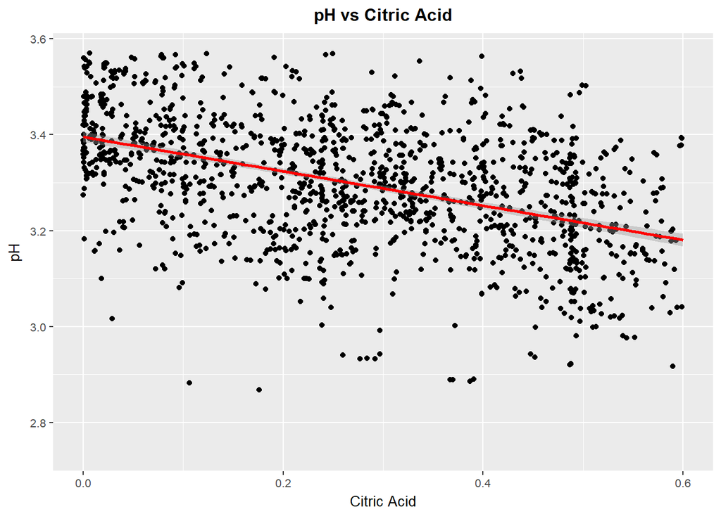

There is a negative relationship between pH value and citric acid. The pH value decreases as the citric acid increases.

The relationship between the 2 values can be visibly observed in the plot easily.

## 5. The relationship between pH and Total Sulfur Dioxide

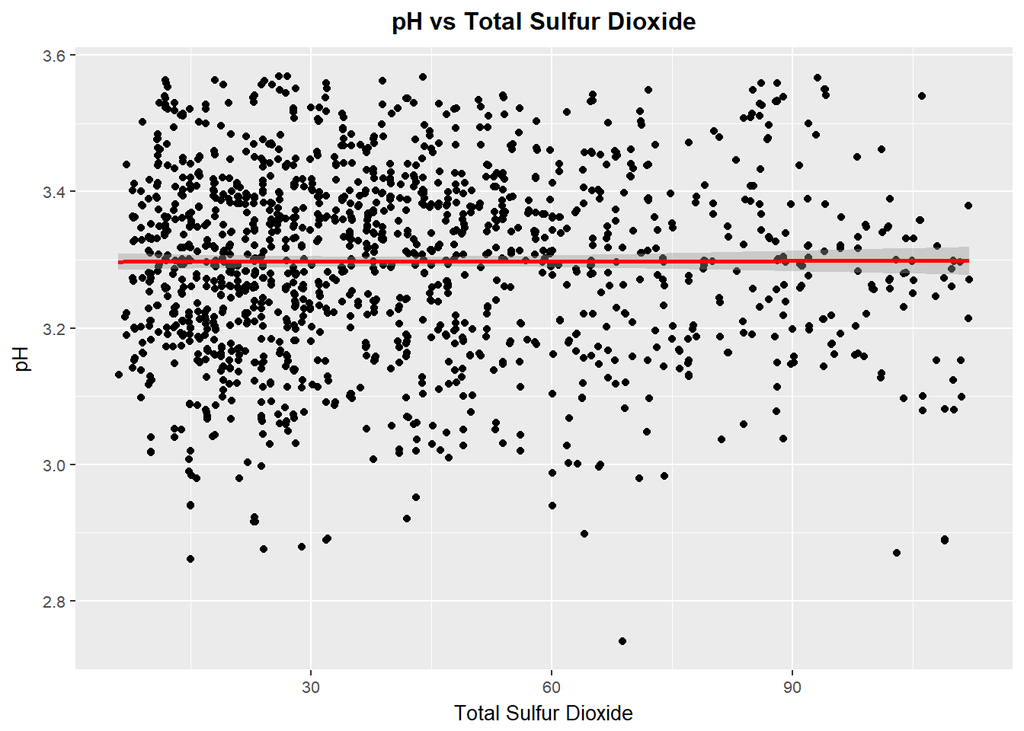

There is no relationship between the pH value and total sulfur dioxide. Since sulfur may be related to affect the pH of solvent in chemistry, I suspected of a relationship. However, pH value is independent from total sulfur dioxide.

# Bivariate Analysis

### Talk about some of the relationships you observed in this part of the investigation. How did the feature(s) of interest vary with other features in the dataset?

The response variable quality is positively correlated with fixed acidity, citric acid and alcohol. In higher quality wines, alcohol an fixed acid is found more.

On the other hand, the quality of the wine decreases when volatile acid, chloride and total sulfur dioxide increases in the wine. There is also a weak negative correlation between pH and the quality of the wine. We can say that high quality wines have lower pH values.

### Did you observe any interesting relationships between the other features (not the main feature(s) of interest)?

I checked the relationship between pH and other acidity variables. The analysis shows us that pH is strongly negative correlated with fixed and citric acid variables, whereas it is positively correlated with volatile acidity. I also suspected if there is any corelation between pH and total sulfur dioxide but there is no such evidence.

Also I assessed the relationship between the total and free sulfur dioxide and there seems a strong positive relationship between these 2 variables.

### What was the strongest relationship you found?

# Multivariate Plots Section

In this chapter, I will analyze the relationships between muliple variables together in a plot.

## The relationship between Quality, Acidity and Alcohol

```
##
##    (8,9.7] (9.7,10.8]  (10.8,15]
##        552        531        516
```

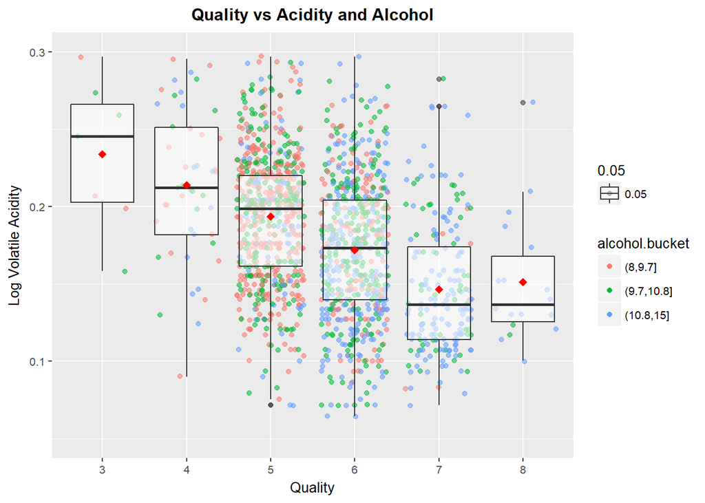

The plot above is created by applying following steps: 1. Bivariate plot of Volatile Acidity vs Quality is used as a base. 2. The continuous varible Alcohol is transformed into a categorical variable. In order to simplify the visibility and prevent complexity, 3 categories of alcohol are created. 3. The points are colored according to alcohol categories.

Tt is observed that the alcohol level is increasing and (log of) volatile acidity is decreasing as the quality of wine increases. (Note that the color pattern is changing from red to blue as the quality increases.)

As a consequence, the volatile acidity and alcohol are changing reversely as the quality of wine changes.

## The relationship between Quality, Acidity and Total Sulfur Dioxide

```
##
##   (6,26]  (26,52] (52,289]
##      531      545      520
```

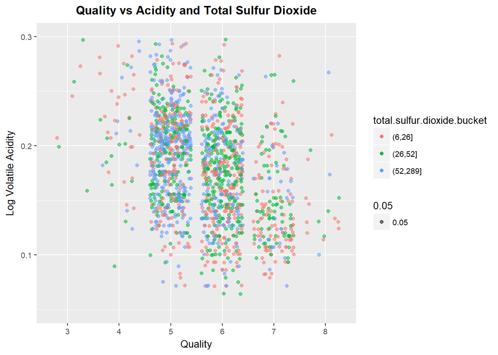

In order to create the above plot, the following steps are followed: 1. Bivariate plot of Volatile Acidity vs Quality is used as a base. 2. The continuous varible Total sulfur dioxide is transformed into a categorical variable. In order to simplify the visibility and prevent complexity, 3 categories of total sulfur dioxide are created. 3. The points are colored according to total sulfur dioxide categories.

In the plot above, the patterns of change of total sulfur dioxide and volatile acidity according to the quality is analysed.

It is observed that the blue color is becoming rare in small amount as the quality level increases, which is an expected result of weak negative correlation between the qualit and total sulfur dioxide.

However, there is no change in color pattern in vertical axis. It means that there is no correlation between sulfur dioxide and volatile acidity. This result also coincides with the heat map.

## The relationship between Quality, Acidity and Chlorides

```
##
##  (0.01,0.073] (0.073,0.085]  (0.085,0.62]
##           516           553           530
```

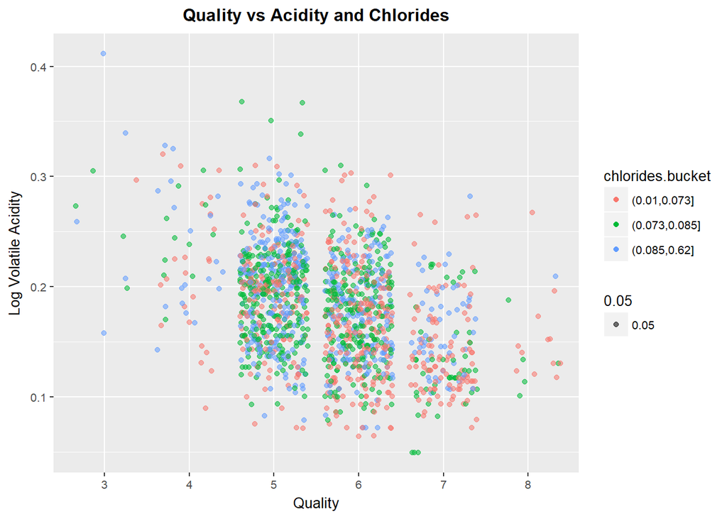

## Linear model depicting the relationship between Quality, Volatile Acidity, Alcohol, Total Sulfur Dioxide and Chlorides

A linear model is created to formulate the linear relationship between Quality and the explanatory variables of Volatile Acidity, Alcohol, Total Sulfur Dioxide and Chlorides.

```
##
## Calls:
## m1: lm(formula = I(quality) ~ I(log(volatile.acidity)), data = RedWineQuality)
## m2: lm(formula = I(quality) ~ I(log(volatile.acidity)) + alcohol,
##     data = RedWineQuality)
## m3: lm(formula = I(quality) ~ I(log(volatile.acidity)) + alcohol +
##     total.sulfur.dioxide, data = RedWineQuality)
## m4: lm(formula = I(quality) ~ I(log(volatile.acidity)) + alcohol +
##     total.sulfur.dioxide + chlorides, data = RedWineQuality)
##
## ====================================================================================
##                                  m1            m2            m3            m4
## ------------------------------------------------------------------------------------
##   (Intercept)                   5.012***      1.938***      2.150***      2.207***
##                                (0.041)       (0.165)       (0.174)       (0.188)
##   I(log(volatile.acidity))     -0.893***     -0.680***     -0.672***     -0.671***
##                                (0.053)       (0.049)       (0.049)       (0.049)
##   alcohol                                     0.309***      0.298***      0.295***
##                                              (0.016)       (0.016)       (0.017)
##   total.sulfur.dioxide                                     -0.002***     -0.002***
##                                                            (0.001)       (0.001)
##   chlorides                                                              -0.305
##                                                                          (0.364)
## ------------------------------------------------------------------------------------
##   R-squared                     0.153         0.311         0.317         0.317
##   adj. R-squared                0.153         0.310         0.315         0.315
##   sigma                         0.743         0.671         0.668         0.668
##   F                           288.647       359.989       246.230       184.813
##   p                             0.000         0.000         0.000         0.000
##   Log-likelihood            -1793.802     -1628.955     -1622.363     -1622.011
##   Deviance                    882.635       718.183       712.286       711.972
##   AIC                        3593.604      3265.910      3254.726      3256.022
##   BIC                        3609.735      3287.419      3281.612      3288.285
##   N                          1599          1599          1599          1599
## ====================================================================================
```

However, when we check the r-squared values, it seems that the linear model is far from covering the variance. This model can not be used to predict the quality level of wine with input values of Volatile Acidity, Alcohol, Total Sulfur Dioxide and Chlorides.

## The relationship between pH, Fixed Acidity, Volatile Acidity and Citric Acid

```
##  (4.5,7.1] (7.1,8.32]  (8.32,16]
##        419        550        630
```

```
##   (-1,0.09] (0.09,0.26] (0.26,0.42]    (0.42,1]
##         403         429         369         398
```

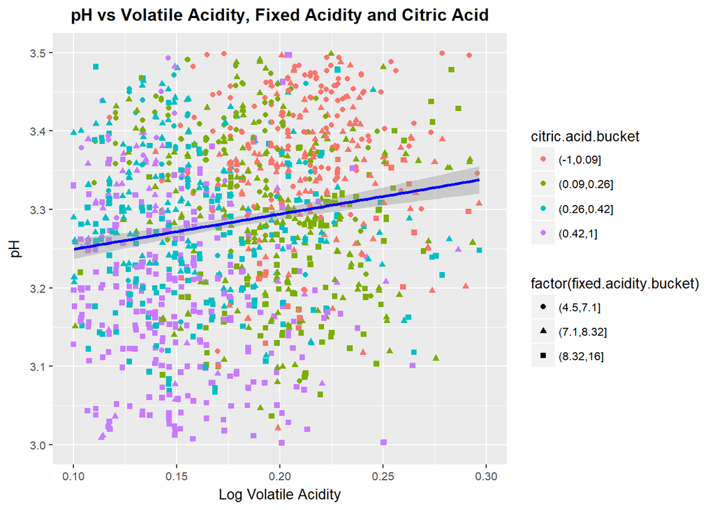

Visual observations depict these findings: 1. pH is in positive correlation with volatile acidity.

2. Citric acid is in negative correlation with both pH and volatile acidity. Note that the color is changing in both x and y axes:
1. Color is transforming from blue and viloet to red and green from left to right, which means a downward change in citric acid level.
2. Color is becoming blue and red from viloet and green from down to top, which also means a decreasing citric acid level as pH increases.
3. Fixed acidity is in negative correlation with both pH and volatile acidity.
1. Note that there are mostly square shapes in the bottom left of the plot. This is where the volatile acidity and pH are both in low levels.
2. The square levels disappear as pH or volatile acidity increases in y or x axis. There are more triangles in bottom right and upper left corners.
3. The fixed acidity is lowest in the upper right corner where the pH and volatile acidity are both highest.
4. Fixed acidity is in positive correlation with citric acid.

## Linear model depicting the relationship between pH, Volatile Acidity, Fixed Acidity and Citric Acid

A linear model is built to estimate the pH value with 3 other acidity variables given as inputs.

```
##
## Calls:
## m1: lm(formula = I(pH) ~ I(log(volatile.acidity + 1)), data = RedWineQuality)
## m2: lm(formula = I(pH) ~ I(log(volatile.acidity + 1)) + fixed.acidity,
##     data = RedWineQuality)
## m3: lm(formula = I(pH) ~ I(log(volatile.acidity + 1)) + fixed.acidity +
##     citric.acid, data = RedWineQuality)
##
## ==========================================================================
##                                      m1            m2            m3
## --------------------------------------------------------------------------
##   (Intercept)                       3.180***      3.771***      3.776***
##                                    (0.014)       (0.020)       (0.020)
##   I(log(volatile.acidity + 1))      0.314***      0.078**      -0.010
##                                    (0.033)       (0.025)       (0.030)
##   fixed.acidity                                  -0.059***     -0.051***
##                                                  (0.002)       (0.002)
##   citric.acid                                                  -0.124***
##                                                                (0.023)
## --------------------------------------------------------------------------
##   R-squared                         0.055         0.470         0.479
##   adj. R-squared                    0.054         0.469         0.478
##   sigma                             0.150         0.113         0.112
##   F                                92.211       706.487       488.984
##   p                                 0.000         0.000         0.000
##   Log-likelihood                  763.903      1225.985      1240.440
##   Deviance                         36.009        20.203        19.841
##   AIC                           -1521.806     -2443.970     -2470.881
##   BIC                           -1505.675     -2422.462     -2443.995
##   N                              1599          1599          1599
## ==========================================================================
```

The r-squared value is 0.479 which is much less than 1 which means that the model is far from estimating the pH value with 3 acidity variables as input.

# Multivariate Analysis

### Talk about some of the relationships you observed in this part of the investigation. Were there features that strengthened each other in terms of looking at your feature(s) of interest?

In the “Quality vs Acidity vs Alcohol” plot, I have sketched the change of alcohol value in the samples on the original “Quality vs Volatile Acidity” plot. It is displayed that alcohol value does not change with volatile acidity but the color only changes as the quality varies.

A similar relationship is displayed in the following 2 plots of displaying the relationship between quality, volatile acidity, total sulfur dioxide and chlorides. The distributions of Both total sulfur dioxide and chlorides does not change with volatile acidity but it decreases only with quality.

### Were there any interesting or surprising interactions between features?

All of the findings are coinciding with the findings in bivariate analysis.

### OPTIONAL: Did you create any models with your dataset? Discuss the strengths and limitations of your model.

I created 2 linear models:

1. A linear model with inputs log of volatile acidity, alcohol, total sulfur dioxide and chlorides, and quality as output.

My linear models has some drawbacks:

- I only took some of the variables included in the dataset to construct the model. For example, I could add the density vaiable also.
- Other factors which definitely affect the quality of a wine are not included in tha dataset. The wineyard, kind of grape, different flavors, bottling process may also be important.
- If all other factors are included, the reliability of the model would increase.
2. A linear model with fixed and volatile acidity and citric acid as inputs and pH as output.
- The second model may also require extra variables to be reliable since the r-squared values seem low.

# Final Plots and Summary

### Plot One

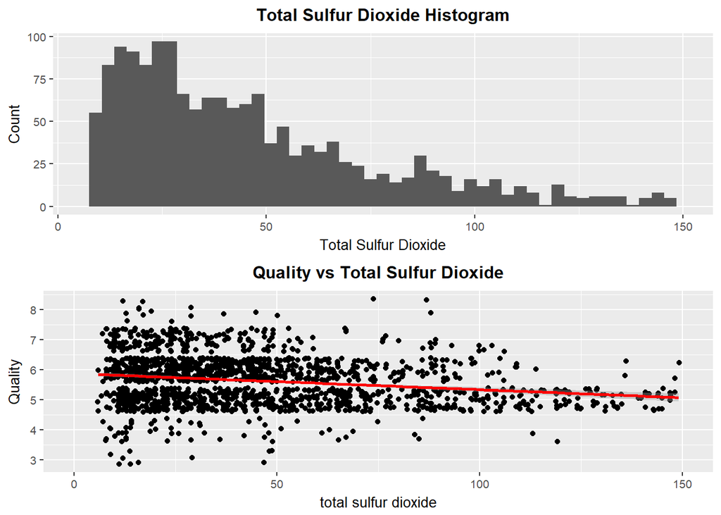

### Description One

It is an interesting finding that total and free sulfur dioxide which are in negative correlation with the quality of the wine have right skewed histograms, in contrat with other variables such as acidity, chlorides and alcohol.

It means that most of the wine samples have low sulfur dioxide levels and this may not be used as a very strong differentiator for setting quality of wine.

This finding is interesting to see the effect of a variable with right or left skewed histogram on the resultant variable with a normal distribution.